# RIVERSEA : État d’avancement

Document à l’appui du formulaire de demande de soutien post-doctorant INRAE

Auteur·rice

Ismaël Lajaaiti

Date de publication

25 septembre 2026

## Contexte, objectifs et originalité

Les changements globaux, le mouvement des espèces et les flux de nutriments transcendent les frontières traditionnelles entre écosystèmes terrestres, d’eau douce et marins (Polis et al. 1997; Gounand et al. 2018). Pourtant ces écosystèmes continuent souvent d’être étudiés séparément (Kavanaugh et al. 2013). En réponse à ce cloisonnement, **le projet RIVERSEA vise à documenter l’impact des pressions anthropiques sur l’ensemble du continuum rivière-mer**. En particulier, RIVERSEA s’appuie sur le cadre des méta-écosystèmes (Loreau et al. 2003) pour **quantifier, à l’échelle de la France, l’impact conjoint des barrages et de l’enrichissement en nutriments sur la structure et le fonctionnement des écosystèmes aquatiques**.

Le besoin d’étudier conjointement les écosystèmes d’eau douce et marins est régulièrement souligné dans la littérature, mais rarement mis en œuvre en pratique, faute de données couvrant l’ensemble du continuum et en raison du cloisonnement historique entre écologie d’eau douce et écologie marine. **L’originalité de RIVERSEA est précisément de faire ce pont entre écologie d’eau douce et marine, afin de couvrir l’ensemble du continuum rivière-mer.**

## Vue d’ensemble du projet

La Figure 1 ci-dessous offre une vue d’ensemble du projet résumant le travail déjà réalisé et les étapes restantes à effectuer.

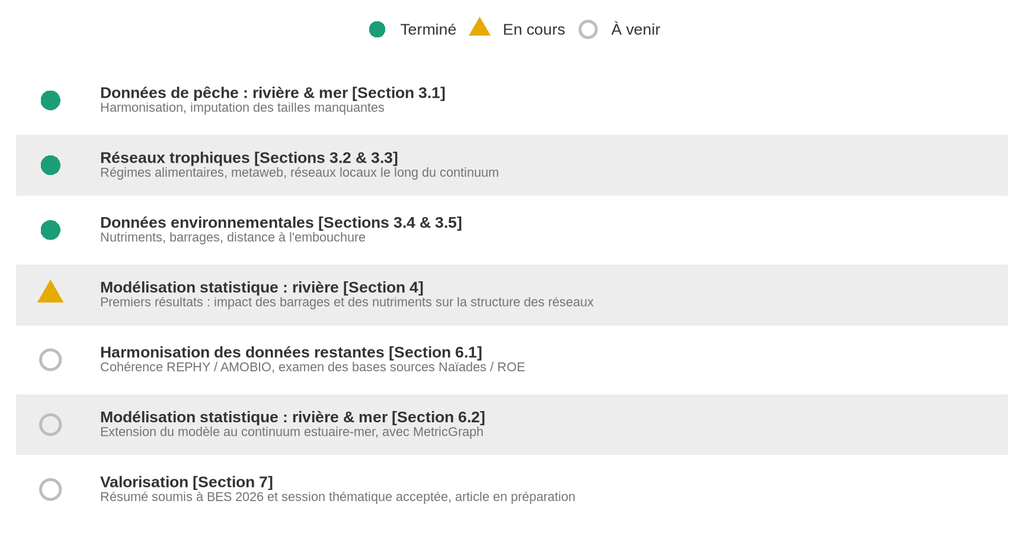

Figure 1: Vue d’ensemble de l’avancement du projet RIVERSEA.

## Travail réalisé

### Données de pêche

Deux campagnes de pêche en mer – Pomet (façades Atlantique et Manche, INRAE) et Nurse (côtes françaises, 1980-2023, IFREMER) – ont été harmonisées avec les opérations en rivière (ASPE, OFB) (Figure 2). Le travail a couvert le nettoyage des noms d’espèces (taxonomie changeante), l’harmonisation des unités (longueurs des poissons, coordonnées GPS) et le contrôle de la qualité des données, avec filtration quand nécessaire (espèces rares, années peu échantillonnées, etc.). Les tailles manquantes ont été imputées par espèce à partir de la distribution des tailles observées, une méthode validée sur des données synthétiques avant application aux données réelles. Ces données de tailles individuelles servent ensuite à la reconstruction des réseaux trophiques.

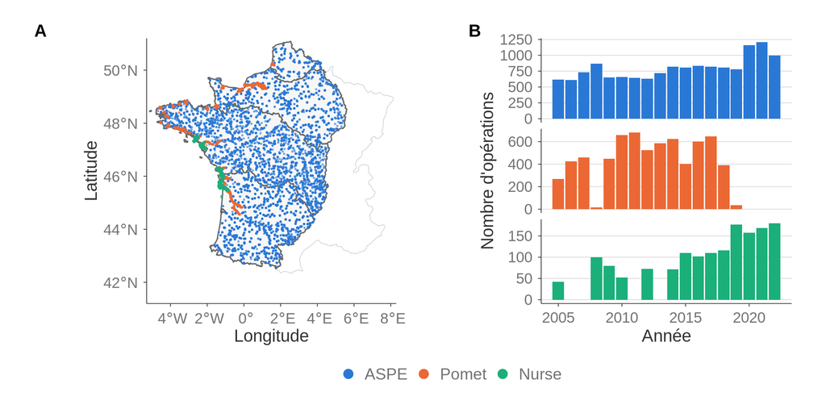

Figure 2: (A) Stations d’échantillonnage le long du continuum rivière-estuaire-mer, colorées par source de données (ASPE, Pomet, Nurse). (B) Couverture temporelle de chaque campagne.

### Table de régime alimentaire

En plus des données de tailles, la reconstruction des réseaux trophiques nécessitait une connaissance du régime alimentaire des 158 espèces de poissons pêchées le long du continuum. Celles-ci allaient de poissons marins benthiques comme la sole commune (*Solea solea*) se nourrissant sur le benthos (polychètes, mollusques, etc.), en passant par des espèces d’eau douce pélagiques comme l’ablette (*Alburnus alburnus*), jusqu’à des espèces anadromes telles que le saumon atlantique (*Salmo salar*) (Figure 3). Ce travail de collecte des informations de régime alimentaire a d’abord été fait automatiquement en extrayant des informations de la base de données FishBase avec le paquet `rfishbase` (Boettiger et al. 2012). Cette première table de régime alimentaire a ensuite été validée, espèce par espèce, par une recherche bibliographique qui a permis de corriger des imprécisions de la base de données FishBase. La table ainsi produite, ainsi que les références bibliographiques la justifiant, seront mises à disposition avec les données en libre accès associées au manuscrit.

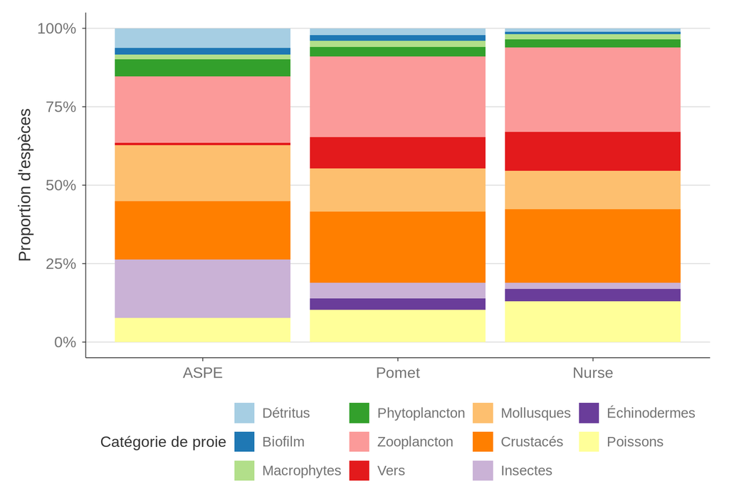

Figure 3: Composition du régime alimentaire des espèces échantillonnées, par campagne (ASPE, Pomet, Nurse) : part de chaque catégorie de proie parmi l’ensemble des catégories consommées par ces espèces. Une espèce est comptée dans une catégorie dès que l’un de ses stades de vie s’en nourrit, et peut donc contribuer à plusieurs catégories.

### Reconstruction et caractérisation des réseaux trophiques

La reconstruction des réseaux trophiques a été faite grâce au paquet `foodwebbuilder`. Celui-ci reconstruit dans un premier temps une *metaweb* (Gravel et al. 2011), représentant l’ensemble des interactions *possibles* entre les espèces du continuum (Figure 4 A), puis reconstruit les réseaux locaux en sous-échantillonnant cette metaweb selon les espèces effectivement présentes à chaque opération de pêche (Figure 4 B-D). Plus de 17 000 réseaux trophiques locaux ont ainsi été reconstruits le long du continuum rivière-mer, de 2005 à 2022 (après filtration des années avec un faible effort d’échantillonnage), à partir de cette table de régime alimentaire. Cette reconstruction repose sur un pipeline automatisé, facilitant l’intégration des données de nouvelles campagnes de pêche. Nous avons ensuite caractérisé la structure de ces réseaux à l’aide de quatre métriques : la richesse spécifique, la longueur de chaîne trophique, la connectance (densité de liens du réseau) et la similarité des régimes alimentaires (Figure 5). Ces métriques capturent de manière synthétique la structure des réseaux, ainsi que la façon dont celle-ci est modifiée par les pressions étudiées. Elles sont également couramment utilisées dans la littérature, ce qui permet de formuler des hypothèses et de comparer nos résultats à ceux d’autres études (Bonnaffé et al. 2024).

Nous soulignons une limite de notre approche : les données de suivi recensent uniquement les poissons présents à chaque opération de pêche, si bien que seule la variabilité de ce compartiment est capturée par nos réseaux. Les compartiments basaux (zooplancton, macro-invertébrés) sont représentés de façon générique ce qui nous empêche – par construction – de capturer la diversité et la dynamique de ces compartiments. Cette simplification a été nécessaire pour couvrir l’ensemble du continuum rivière-mer à large échelle spatiale et temporelle.

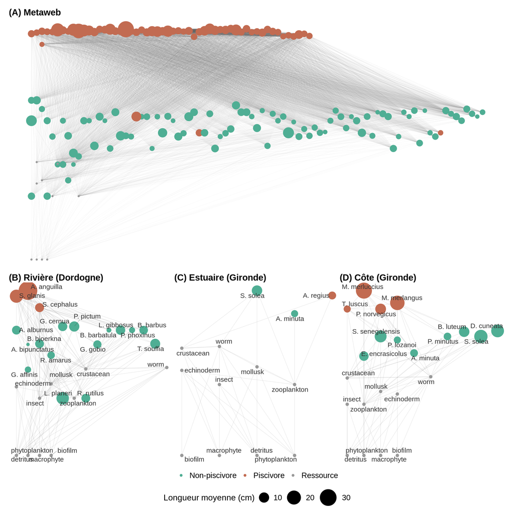

Figure 4: (A) Metaweb représentant l’ensemble des interactions trophiques possibles entre les espèces du continuum rivière-mer, organisées par niveau trophique (des ressources basales en bas aux poissons prédateurs en haut). Les nœuds du réseau sont colorés selon le statut piscivore et leur taille reflète la longueur moyenne des individus. (B-D) Exemples de réseaux trophiques locaux reconstruits en trois points du continuum, le long de la Gironde : en rivière, dans l’estuaire et sur la côte. Par souci de lisibilité, chaque espèce est représentée, agrégée sur l’ensemble de ses classes de taille ; le modèle sous-jacent distingue cependant plusieurs classes de taille par espèce, dont les interactions de prédation sont déterminées par une fenêtre de prédation.

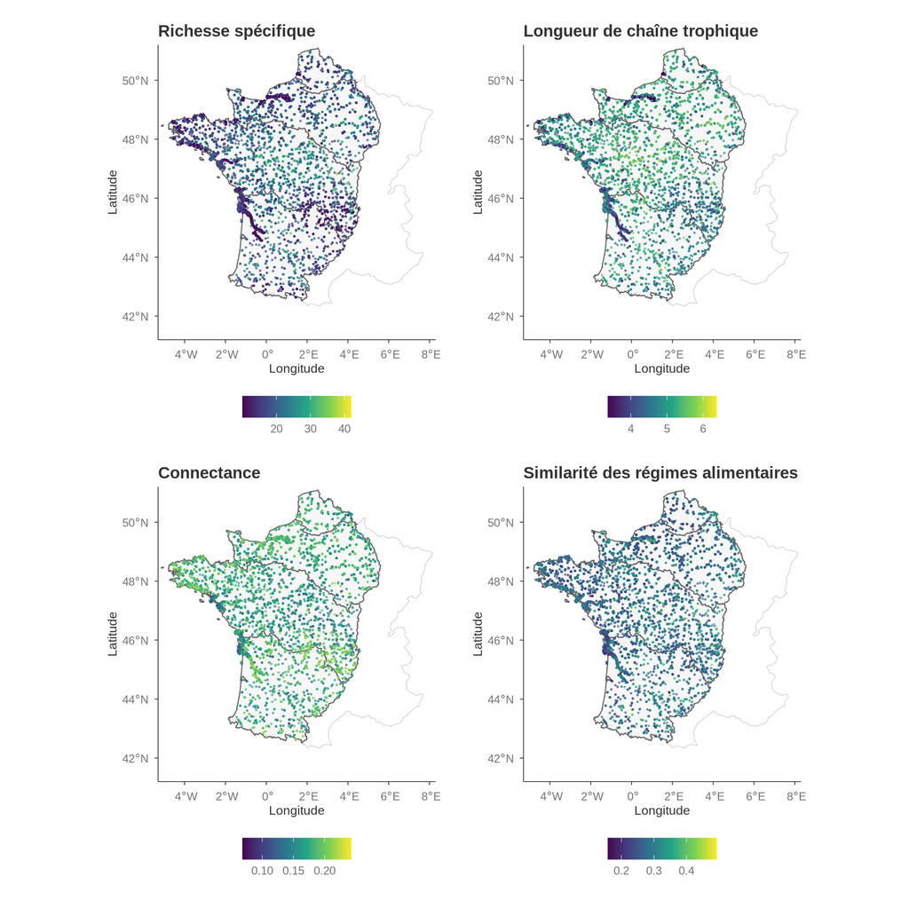

Figure 5: Métriques de structure des réseaux trophiques locaux (richesse spécifique, longueur de chaîne trophique, connectance, similarité des régimes alimentaires), une opération par point.

### Données environnementales

Pour la collecte des données environnementales, deux sources principales ont été mobilisées : 1) la base **AMOBIO**, pour les pressions liées aux barrages et la qualité de l’eau en rivière ; 2) la base **REPHY**, pour les nutriments côtiers. Nous détaillons le travail effectué sur chacune de ces bases ci-dessous.

**AMOBIO** — Produite par l’INRAE et l’OFB (programme 2021-2024), AMOBIO fournit, pour des milliers de stations du réseau hydrographique français, des indicateurs de pression liés aux barrages ainsi que des mesures de qualité de l’eau, construits à partir des réseaux de surveillance DCE (ROE, CARHYCE, SYRAH-CE). Nous avons croisé ces indicateurs avec nos données de structure des réseaux trophiques (ASPE), en nous restreignant aux bassins connectés à l’Atlantique et à la Manche. Ces données étant déjà disponibles à nos stations de pêche, aucune étape d’interpolation n’a été nécessaire ici (voir toutefois les perspectives). L’impact des barrages est mesuré par la distance au barrage le plus proche (amont/aval) et par la hauteur cumulée des barrages en aval, un indicateur de l’isolement d’un site vis-à-vis de la côte. Les concentrations en nutriments (phosphore total, ammonium, nitrite, nitrate, azote Kjeldahl) ont été comparées aux seuils réglementaires de qualité de l’eau. La qualité des données a été contrôlée (valeurs aberrantes, couverture spatiale et temporelle) ; la couverture temporelle est en particulier bonne depuis 2005.

**REPHY** — Piloté par l’Ifremer depuis 1987, REPHY surveille la qualité physico-chimique et le phytoplancton des eaux côtières françaises. Nous en avons extrait trois paramètres pertinents pour notre étude (ammonium, nitrite+nitrate et phosphate), nettoyés puis restreints aux mesures de surface et de bonne qualité. Nous avons également vérifié que les changements de protocole de mesure n’introduisaient pas de biais temporel dans les données. Ces données ont ensuite été interpolées dans l’espace et le temps jusqu’aux opérations de pêche en estuaire et en mer (Nurse, Pomet ; Figure 6). Nous avons fait cette interpolation à l’aide d’un modèle bayésien spatio-temporel implémenté avec le paquet `R-INLA` (Lindgren et Rue 2015). L’utilisation d’INLA à cette étape avait un double intérêt : éprouver l’outil afin d’évaluer son applicabilité aux analyses à plus grande échelle prévues pour la suite du projet, et bénéficier des distributions *a posteriori* qu’il produit pour les valeurs interpolées (plutôt qu’une simple estimation ponctuelle), ce qui permettra de propager correctement l’incertitude de cette interpolation dans les modèles en aval. L’ajout de la salinité comme covariable améliore nettement les prédictions en estuaire ; la validation croisée par station confirme que ce modèle surpasse une prédiction naïve pour les trois paramètres.

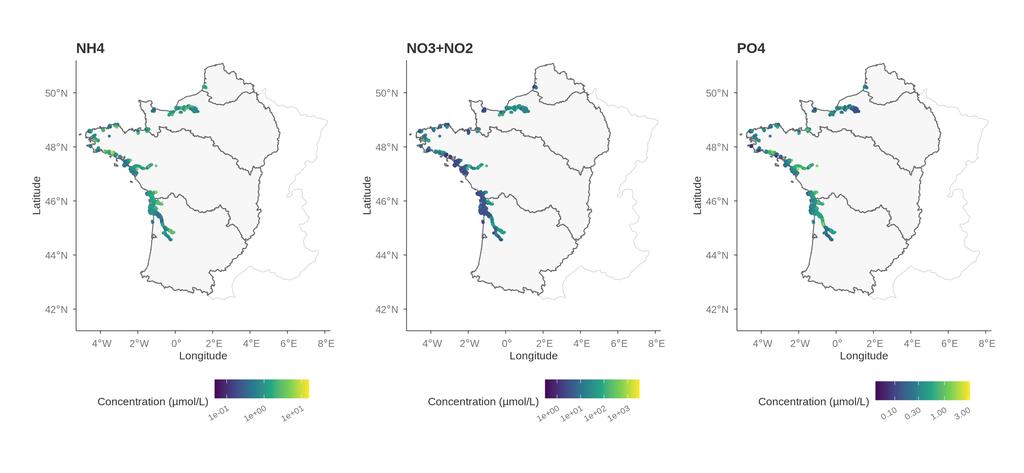

Figure 6: Concentrations en nutriments interpolées aux opérations de pêche en estuaire et en mer, pour les trois paramètres retenus.

### Calcul de la distance à l’embouchure

Afin de rendre compte de la variabilité de l’impact des pressions le long du continuum rivière-mer, une mesure de *position* le long de ce continuum était nécessaire. Pour cela, nous avons calculé la distance à l’embouchure la plus proche pour chaque opération de pêche, en mer comme en rivière, sur quatre bassins versants (Loire, Adour-Garonne, Seine, Escaut-Somme ; Figure 7 C). Les embouchures sont définies comme les points de transition entre le réseau fluvial et les masses d’eau côtières ou de transition. Deux méthodes différentes ont été utilisées, pour les opérations en rivière et en mer respectivement.

**Opérations en rivière** — Pour ces opérations, il était nécessaire de tenir compte des distances *hydrographiques* le long du réseau, et non de la distance à vol d’oiseau. Nous avons donc utilisé, pour chaque bassin versant, un algorithme de plus court chemin sur le graphe du réseau hydrographique (Figure 7 A).

**Opérations en mer** — Ici, la distance euclidienne n’était pas non plus adaptée, car elle ne tient pas compte de la topologie du littoral (îles, échancrures côtières). Nous avons donc construit un maillage fin excluant les terres sur l’intégralité du littoral Atlantique et Manche, puis calculé les distances le long de ce maillage, ce qui permet de contourner correctement les côtes et les îles (Figure 7 B).

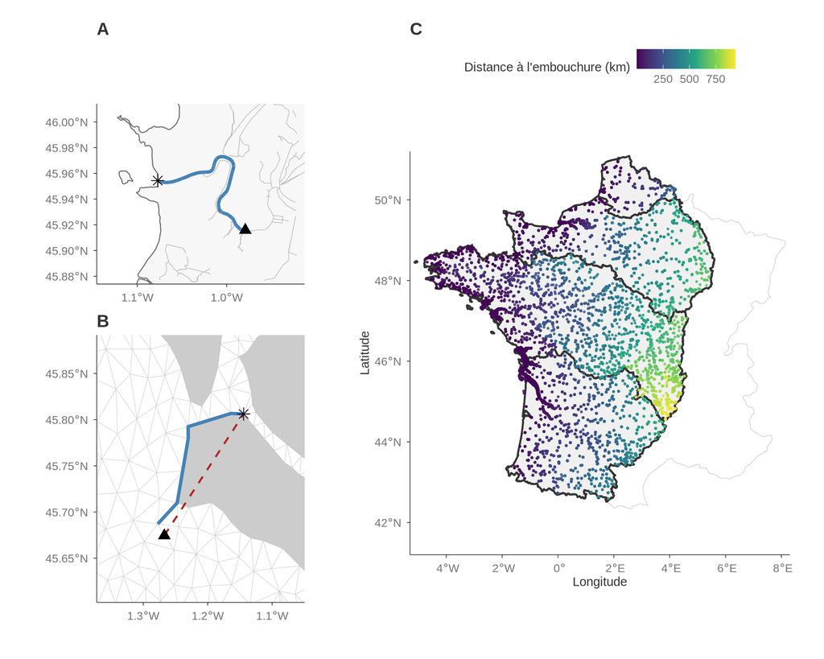

Figure 7: Calcul de la distance à l’embouchure. (A) Exemple de plus court chemin le long du réseau hydrographique (bleu), pour une opération en rivière (triangle) jusqu’à l’embouchure atteinte (étoile), le reste du réseau hydrographique local étant représenté en gris clair. (B) Même principe pour une opération en mer, le long du maillage côtier excluant les terres (gris foncé) ; l’exemple choisi illustre un cas où la distance à vol d’oiseau (pointillés rouges) traverserait la terre. (C) Distance à l’embouchure de l’ensemble des opérations, en rivière et en mer, sur les quatre bassins versants retenus (bordures grises).

### Modélisation statistique spatiale

Une première version du modèle spatial bayésien (INLA) reliant la structure des réseaux trophiques, les barrages et les nutriments a été implémentée sur la base des données désormais consolidées (voir les résultats préliminaires en Section 4). Après étude approfondie, INLA nous est apparu comme l’outil le mieux adapté à cette tâche : sa rapidité (approximation de Laplace) permet de passer à l’échelle sur notre jeu de données de plus de 17 000 points, tout en conservant une grande flexibilité de modélisation. INLA permet également de tenir compte de l’autocorrélation spatiale, qui pourrait sinon biaiser d’éventuels effets fixes, même si la forme définitive de cette composante spatiale reste encore à déterminer (voir perspectives). La participation d’I. Lajaaiti à un atelier sur la modélisation spatio-temporelle lors de son arrivée début février, complétée par la pratique acquise en interpolant les données REPHY, lui a permis de prendre ces outils en main. Nous avons toutefois identifié d’autres approches intéressantes pour la modélisation spatio-temporelle, telles que SSN2 (Dumelle et al. 2024) et glmmTMB (Brooks et al. 2017), auxquelles nous pourrons comparer INLA si besoin.

De premières analyses exploratoires ont déjà révélé des effets significatifs des nutriments et des barrages sur les communautés de poissons le long du continuum. Nous détaillons ces premiers résultats dans la prochaine partie.

## Résultats préliminaires

### Présentation du cas d’étude

Une fois les données préparées, nous nous sommes intéressés à un cas d’étude. L’objectif est double : nous cherchons à 1) mieux comprendre les données et leurs limitations ; et 2) éprouver les outils statistiques que nous prévoyons d’utiliser. L’objectif scientifique est de **quantifier l’impact des barrages et de l’enrichissement en nutriments sur les réseaux trophiques de poissons le long du continuum de la rivière, à l’échelle de la France**. Nous limitons volontairement la question au continuum de la rivière, allant de l’amont à l’aval mais excluant les estuaires et les côtes.

Avant toute analyse, nous formulons trois hypothèses :

- **H1 – Les nutriments ont un effet unimodal sur la structure des réseaux trophiques** ; à faibles concentrations un apport en nutriments complexifie les réseaux trophiques en augmentant la productivité primaire, mais – à haute concentrations – les nutriments simplifient les réseaux en détériorant les conditions hydrochimiques.
- **H2 – En bloquant les espèces migratrices en aval, les barrages simplifient les réseaux trophiques en amont** ; on s’attend – proche de l’embouchure – à un effet barrière des barrages *aval* fort et négatif sur la complexité des réseaux, et inversement à un effet barrière des barrages *amont* fort et positif sur la complexité des réseaux ; de plus, on s’attend à une atténuation de ces deux effets en remontant de l’aval vers l’amont.
- **H3 – Les effets des pressions sur la structure des réseaux trophiques passent en partie par la richesse spécifique** ; pour des raisons de contraintes topologiques, on s’attend à ce que la richesse spécifique agisse comme médiateur d’une partie de l’effet des pressions sur la structure des réseaux ; on s’attend également à des *effets directs* des pressions sur les mesures de structure des réseaux, car celles-ci peuvent avoir un impact variable sur les différents groupes trophiques (e.g., barrages et espèces migratrices qui sont souvent en haut des réseaux trophiques).

### Méthodes

Afin de tester ces hypothèses, nous nous appuyons sur les données biologiques et environnementales de rivière présentées plus haut. Ces données couvrent quatre bassins versants : Loire, Adour-Garonne, Seine et Escaut-Somme. Nous détaillons dans ce qui suit les données sélectionnées.

**Structure des réseaux trophiques –** Nous quantifions la structure des réseaux trophiques par leur connectance (nombre de liens divisé par la richesse spécifique au carré) et leur longueur moyenne de chaîne trophique (calculée par le paquet `cheddar`).

**Nutriments –** Pour capturer l’effet des nutriments, nous utilisons la concentration en nitrate et en phosphate. Ce sont les deux nutriments testés qui montrent des effets robustes sur la structure des réseaux trophiques dans nos modèles préliminaires ; l’ammonium est écarté en raison d’une forte colinéarité avec les autres nutriments, et le nitrite ne montre d’effet significatif dans aucun des modèles testés.

**Habitat –** Nous incluons aussi un ensemble de variables physiques qui structurent fortement les écosystèmes le long du continuum amont-aval : la distance hydrographique à la source, l’altitude et la largeur du cours d’eau.

Par souci de simplicité, nous faisons une analyse en cas complets (*complete-case analysis*), enlevant ainsi toutes les opérations de pêche avec des covariables manquantes. Cela nous donne un jeu de données de 2789 opérations, allant de 2005 à 2021.

Avec ces données, nous réalisons trois modèles : un pour la richesse spécifique, un pour la connectance et un pour la longueur de chaîne trophique. En plus d’inclure les effets des covariables listées ci-dessus, les modèles de connectance et de longueur de chaîne trophique incluent également la richesse spécifique – afin de tester l’hypothèse H3 –, et les trois modèles incluent un effet aléatoire année et bassin versant – afin de contrôler pour des effets résiduels temporels ou géographiques. De plus, afin de tester l’hypothèse H1, nous incluons des termes quadratiques pour les nutriments, ce qui permet de valider un effet dose éventuel. Enfin, afin de tester l’hypothèse H2, nous incluons une interaction entre les effets barrière des barrages et la distance à l’embouchure.

Nous donnons l’expression formelle des modèles utilisés dans ce qui suit. Notons $\mathbf{x}_i$ le vecteur de covariables du site $i$ :

$$\begin{aligned}
\mathbf{x}_i = \big(\
& \text{altitude}_i,\ \text{largeur}_i,\ \text{distance}_i, \\
& \text{nitrate}_i,\ \text{nitrate}_i^2,\ \text{phosphate}_i,\ \text{phosphate}_i^2, \\
& \text{barrage}_i^{\text{amont}},\ \text{barrage}_i^{\text{aval}},\
\text{barrage}_i^{\text{amont}} \cdot \text{distance}_i,\
\text{barrage}_i^{\text{aval}} \cdot \text{distance}_i\,\big)^\top.
\end{aligned}$$

De plus, on note $\text{année}_i$, $\text{bassin}_i$, $\text{SPDE}_i$ respectivement les effets aléatoires année et bassin versant, et le champ spatial gaussien (SPDE). Nous pouvons alors écrire les différents modèles pour nos trois structures de réseaux. Nous choisissons de modéliser la richesse spécifique par une gaussienne, car elle est non bornée et sa distribution observée est en cloche ; la connectance par une loi beta, car elle est bornée entre 0 et 1 ; et la longueur de chaîne trophique par un modèle en deux parties – une partie catégorielle et une partie gaussienne conditionnelle – car sa distribution observée est trimodale.

**Richesse spécifique** (gaussien) :
$$\log S_i \sim \mathcal{N}(\mu_i, \sigma_i)$$
$$\mu_i = \mathbf{x}_i^\top \boldsymbol\beta + \text{année}_i + \text{bassin}_i
+ \text{SPDE}_i$$

**Connectance** (beta, lien logit) – la richesse spécifique intervient comme covariable médiatrice (coefficient $\gamma_r$), afin de tester l’hypothèse H3 :
$$\text{connectance}_i \sim \text{Beta}(\mu_i, \phi)$$
$$\text{logit}(\mu_i) = \beta_0 + \gamma_r \, \text{richesse}_i + \mathbf{x}_i^\top
\boldsymbol\gamma + \text{année}_i + \text{bassin}_i + \text{SPDE}_i$$

**Longueur de chaîne trophique** – modélisée en deux étapes, la distribution étant trimodale. On modélise d’abord la profondeur de prédation $D_i \in \{1, 2, 3\}$ (aucun poisson mangé par le sommet du réseau, un poisson non-piscivore mangé, un poisson piscivore mangé) par un modèle ordinal :
$$\text{logit}\left[P(D_i \le k)\right] = \theta_k - \eta_i, \quad k \in \{1, 2\}$$
$$\eta_i = \gamma_r \, \text{richesse}_i + \mathbf{x}_i^\top \boldsymbol\beta
+ \text{année}_i + \text{bassin}_i + \text{SPDE}_i$$
puis, conditionnellement à $D_i$, un modèle gaussien pour la longueur de chaîne trophique avec une ordonnée à l’origine propre à chaque catégorie :
$$\text{longueur}_i \mid D_i \sim \mathcal{N}(\mu_{i, D_i}, \sigma^2)$$
$$\mu_{i, k} = \alpha_k + \gamma_r \, \text{richesse}_i + \mathbf{x}_i^\top
\boldsymbol\gamma + \text{année}_i + \text{bassin}_i + \text{SPDE}_i$$

**Calcul des effets marginaux –** Dans ce dernier modèle, l’effet total d’une covariable sur la longueur de chaîne trophique combine son effet sur le mode ($D_i$) et son effet au sein du mode : la longueur de chaîne trophique prédite au site $i$, $\mathbb{E}[\text{longueur}_i \mid \mathbf{x}_i]$, s’obtient en moyennant la prédiction de chaque catégorie $\mu_{i, k}$ par sa probabilité $P(D_i = k \mid \mathbf{x}_i)$, soit :

$$\mathbb{E}[\text{longueur}_i \mid \mathbf{x}_i] = \sum_{k=1}^{3} P(D_i = k \mid
\mathbf{x}_i) \cdot \mu_{i, k}.$$

Par conséquent, cet effet total est une fonction non linéaire de $\mathbf{x}_i$, puisque les poids $P(D_i = k \mid \mathbf{x}_i)$ en dépendent eux-mêmes. Nous résumons donc l’effet de chaque covariable $x_j$ par son effet marginal moyen (*average marginal effect*, AME), défini comme la dérivée de l’espérance du modèle par rapport à $x_j$, moyennée conjointement sur l’ensemble des sites et sur les tirages de la loi postérieure :

$$\text{AME}_j = \left\langle \frac{\partial\, \mathbb{E}[y_i \mid
\mathbf{x}_i]}{\partial x_{ij}} \right\rangle_{\text{site, tirage}}.$$

La dérivée partielle est en pratique approximée par une différence finie.

### Résultats et discussion

Nous regardons à présent comment chaque covariable affecte les trois mesures de structure des réseaux trophiques, à travers l’AME défini plus haut.

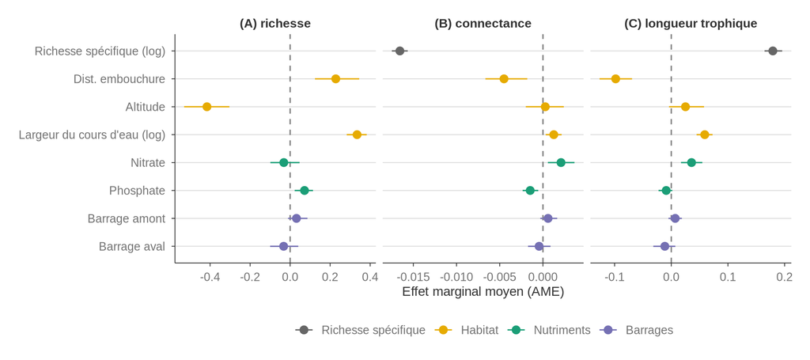

Figure 8: Effet marginal moyen (AME) de chaque covariable sur les trois métriques de structure des réseaux trophiques : (A) richesse spécifique, (B) connectance, (C) longueur trophique. Les covariables sont colorées par catégorie (richesse spécifique, habitat, nutriments, barrages). La richesse spécifique n’est pas incluse comme covariable du modèle de richesse (ligne vide). Les barres horizontales représentent l’intervalle de crédibilité à 95%. Les termes d’interaction du modèle sont représentés en Figure 9.

On observe que les variables d’habitat structurent très fortement les réseaux trophiques (Figure 8). En particulier, la richesse spécifique augmente avec la largeur des cours d’eau et la distance à l’embouchure, tandis qu’elle diminue avec l’altitude (Figure 8 A). La richesse spécifique structure aussi fortement les réseaux : les réseaux riches ont de plus longues chaînes trophiques et une plus faible connectance (Figure 8 B, C). De plus, les nutriments ont des effets directs notables sur les réseaux : en moyenne, le phosphate est associé à des communautés plus riches et moins connectées (Figure 8 A, B), tandis que le nitrate est associé à des réseaux à plus forte connectance et de plus longue chaîne trophique (Figure 8 B, C). Les effets moyens des barrages sont nuls (Figure 8 A-C), mais ceux-ci peuvent cacher des interactions avec la distance à l’embouchure. Nous explorons ces interactions dans ce qui suit.

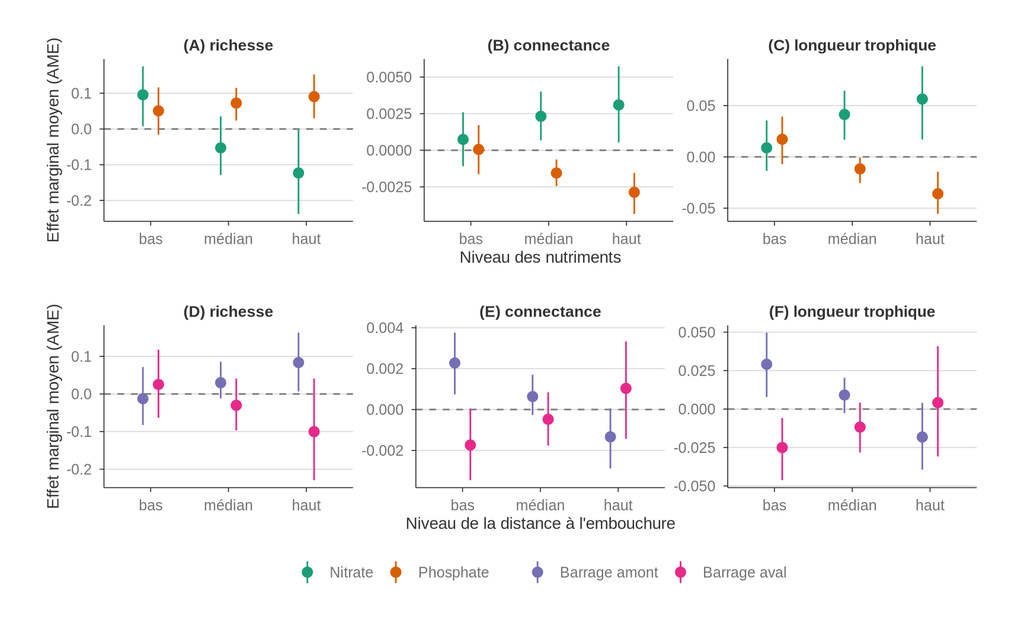

La Figure 9 détaille ces deux interactions. Le nitrate et le phosphate ont un effet quadratique sur eux-mêmes (auto-interaction, afin de tester H1 ; Figure 9 A-C), et les barrages ont un effet en interaction avec la distance à l’embouchure (afin de tester H2 ; Figure 9 D-F).

Ce cas d’étude répond aux deux objectifs fixés en introduction de cette partie : il nous a permis de mieux cerner les données disponibles et leurs limites, et de valider notre chaîne d’analyse statistique. En particulier, il sera intéressant d’affiner les mesures de barrages pour tenir compte de leur passabilité au-delà de leur hauteur (e.g., passe à poissons). Concernant les nutriments, la question de la fenêtre temporelle utilisée pour calculer leur moyenne (ici un an avant l’opération) reste ouverte : des analyses de sensibilité seront nécessaires pour mieux comprendre à quelle échelle temporelle ces derniers agissent sur les communautés écologiques. De même, la composante spatiale du modèle repose actuellement sur un champ spatial gaussien continu (SPDE), qui suppose une distance euclidienne entre les sites ; cette structure devra être affinée pour tenir compte de la distance hydrographique le long du réseau fluvial, plus pertinente pour ce système (voir perspectives). Les résultats obtenus, globalement cohérents avec nos hypothèses, nous encouragent à étendre cette approche à l’ensemble du continuum rivière-mer. Nous discutons les difficultés rencontrées lors de ce travail, ainsi que les perspectives qu’il ouvre, dans ce qui suit.

## Difficultés rencontrées

La principale difficulté rencontrée tient à la diversité et à la complexité des données que le projet nécessite d’intégrer. Par essence, le continuum rivière-mer impose de combiner des données d’eau douce et marines, ce qui a une double implication en termes d’effort : doubler le nombre de bases de données à traiter (pêche en mer et en rivière, par exemple), et harmoniser ces dernières entre elles (unités, protocoles de pêche, etc.). Cette double implication vaut aussi bien pour les données biologiques que pour les données environnementales (AMOBIO en rivière, REPHY en mer). Considérer l’ensemble du continuum implique également de prendre en compte toutes les espèces qui s’y trouvent, ce qui allonge d’autant la liste des espèces pour lesquelles il faut rassembler des informations (158 espèces dans notre étude, contre 52 chez Bonnaffé et al. (2024), qui étudient les réseaux trophiques de rivière en France). Ces différents points n’ont pas été bloquants, mais ont considérablement allongé la phase de préparation des données. C’est ce travail, ainsi que la richesse des données restant à exploiter, qui motive la demande de prolongation du contrat.

## Perspectives

Nous détaillons ici, dans l’ordre chronologique, les prochaines étapes prévues avant la fin du contrat initial (fin août 2027). Un calendrier détaillé de cette prolongation est fourni dans le formulaire qui accompagne ce document.

### Finalisation de l’harmonisation des données

Dans un premier temps, il sera nécessaire d’achever l’harmonisation des différentes sources de données. En particulier, les données de nutriments des bases REPHY et AMOBIO restent à l’heure actuelle incohérentes entre elles. Par exemple, AMOBIO mesure séparément le nitrite et le nitrate, alors que REPHY ne fournit que leur somme. Nous prévoyons également d’examiner les bases de données que le projet AMOBIO agrège : Naïades pour les nutriments en rivière, ROE pour les barrages. Cela nous permettra de mieux comprendre le détail de ces données et leurs éventuelles limites. Si leur utilisation s’avère aisée, et que le temps le permet, nous prévoyons d’affiner le calcul de nos métriques d’impact des pressions anthropiques en partant directement de ces bases de données, plutôt que d’utiliser les mesures indirectes fournies par AMOBIO. Cette étape sera suivie d’une phase de modélisation statistique des données, afin de quantifier l’impact des pressions sur les écosystèmes le long du continuum rivière-mer. Nous détaillons en quoi consistera cette étape dans ce qui suit.

### Modélisation statistique

Ici, nous partirons des mesures d’impact des pressions (barrages et nutriments) afin de modéliser leur impact sur les écosystèmes le long du continuum rivière-mer. Nous réaliserons cette étape avec le paquet `R-INLA`. Nous choisissons cet outil pour trois raisons : 1) il utilise un cadre bayésien qui permet de mieux propager l’incertitude (par exemple des mesures de nutriments interpolées), et de générer des scénarios contrefactuels (par exemple, pour estimer l’impact de l’arasement d’un barrage) ; 2) il est rapide car basé sur l’approximation de Laplace plutôt que sur un algorithme de Monte-Carlo, ce qui facilite le passage à l’échelle ; 3) il permet de tenir compte de l’autocorrélation spatiale dans le processus de modélisation. Modéliser proprement ce phénomène permet de mieux capturer les effets des pressions, qui seraient autrement biaisés (F. Dormann et al. 2007). De plus, INLA permet de construire des modèles hiérarchiques et donc de tenir compte de la variabilité entre bassins versants et protocoles de pêche de manière optimale, en les intégrant comme effets aléatoires.

L’exercice de modélisation qui nous attend est particulièrement ardu, car il nécessite de prendre en compte la topologie du bassin hydrographique dans le terme d’autocorrélation spatiale. Deux opérations ont une plus grande chance d’être similaires si elles sont proches en distance hydrographique plutôt qu’en distance euclidienne, comme cela est le plus souvent fait. Si certaines études ont déjà considéré ce problème statistique (Gimenez 2024), peu l’ont fait à l’échelle de plusieurs bassins versants (Peterson et Hoef 2010). Pour ce faire, nous utiliserons le nouveau paquet `MetricGraph` (Bolin et al. 2023). Cette phase de modélisation devrait occuper les premiers mois de l’année 2027.

## Valorisation

Plusieurs communications ont déjà été réalisées afin de présenter le projet : à l’ANR WINE, qui s’intéresse à la dynamique des réseaux trophiques dans des réseaux spatiaux, et à l’AG de l’UMR DECOD ; un résumé a également été soumis pour présenter les premiers résultats à la conférence BES 2026. Une fois les résultats finalisés (horizon printemps 2027), un article sera aussi soumis dans une revue d’écologie généraliste à fort impact. Enfin, cet automne, un article de vulgarisation de synthèse sur le continuum rivière-mer sera proposé à Planète-Vie, dont l’éditeur a déjà manifesté son intérêt pour le sujet.

## Les références

Boettiger, C., D. T. Lang, et P. C. Wainwright. 2012. « rfishbase: exploring, manipulating and visualizing FishBase data from R ». *Journal of Fish Biology* 81 (6): 2030‑39. https://doi.org/10.1111/j.1095-8649.2012.03464.x.

Bolin, David, Alexandre B. Simas, et Jonas Wallin. 2023. *Gaussian Whittle-Matérn fields on metric graphs*. https://doi.org/10.48550/arXiv.2205.06163.

Bonnaffé, Willem, Alain Danet, Camille Leclerc, Victor Frossard, Eric Edeline, et Arnaud Sentis. 2024. « The interaction between warming and enrichment accelerates food-web simplification in freshwater systems ». *Ecology Letters* 27 (8): e14480. https://doi.org/10.1111/ele.14480.

Brooks, Mollie E., Kasper Kristensen, Koen J. van Benthem, et al. 2017. « The R Journal: glmmTMB Balances Speed and Flexibility Among Packages for Zero-inflated Generalized Linear Mixed Modeling ». *The R Journal* 9 (2): 378‑400. https://doi.org/10.32614/RJ-2017-066.

Dumelle, Michael, Erin E. Peterson, Jay M. Ver Hoef, Alan Pearse, et Daniel J. Isaak. 2024. « SSN2: The next generation of spatial stream network modeling in R ». *Journal of Open Source Software* 9 (99): 6389. https://doi.org/10.21105/joss.06389.

F. Dormann, Carsten, Jana M. McPherson, Miguel B. Araújo, et al. 2007. « Methods to account for spatial autocorrelation in the analysis of species distributional data: a review ». *Ecography* 30 (5): 609‑28. https://doi.org/10.1111/j.2007.0906-7590.05171.x.

Gimenez, Olivier. 2024. « Spatial Occupancy Models for Data Collected on Stream Networks ». *Aquatic Conservation: Marine and Freshwater Ecosystems* 34 (11): e70013. https://doi.org/10.1002/aqc.70013.

Gounand, Isabelle, Eric Harvey, Chelsea J. Little, et Florian Altermatt. 2018. « Meta-Ecosystems 2.0: Rooting the Theory into the Field ». *Trends in Ecology & Evolution* 33 (1): 36‑46. https://doi.org/10.1016/j.tree.2017.10.006.

Gravel, Dominique, François Massol, Elsa Canard, David Mouillot, et Nicolas Mouquet. 2011. « Trophic theory of island biogeography ». *Ecology Letters* 14 (10): 1010‑16. https://doi.org/10.1111/j.1461-0248.2011.01667.x.

Kavanaugh, Maria T., Gordon W. Holtgrieve, Helen Baulch, et al. 2013. « A Salty Divide Within Aslo? » *Limnology and Oceanography Bulletin* 22 (2): 34‑37. https://doi.org/10.1002/lob.201322233.

Lindgren, Finn, et Håvard Rue. 2015. « Bayesian Spatial Modelling with R-INLA ». *Journal of Statistical Software* 63 (février): 1‑25. https://doi.org/10.18637/jss.v063.i19.

Loreau, Michel, Nicolas Mouquet, et Robert D. Holt. 2003. « Meta-ecosystems: a theoretical framework for a spatial ecosystem ecology ». *Ecology Letters* 6 (8): 673‑79. https://doi.org/10.1046/j.1461-0248.2003.00483.x.

Peterson, Erin E., et Jay M. Ver Hoef. 2010. « A mixed-model moving-average approach to geostatistical modeling in stream networks ». *Ecology* 91 (3): 644‑51. https://doi.org/10.1890/08-1668.1.

Polis, Gary A., Wendy B. Anderson, et Robert D. Holt. 1997. « Toward an Integration of Landscape and Food Web Ecology: The Dynamics of Spatially Subsidized Food Webs ». *Annual Review of Ecology, Evolution, and Systematics* 28 (Volume 28, 1997): 289‑316. https://doi.org/10.1146/annurev.ecolsys.28.1.289.